# Introduction to Managing Users

Ever heard a retailer advertise as a “one stop shop” for anything you want? The idea is they have so much stuff that whatever you want is probably there. Liferay’s Control Panel is like this. Where do you create Users, Organizations, or Sites? Where do you configure permissions and plugins and pretty much anything else? You do it from the Control Panel.

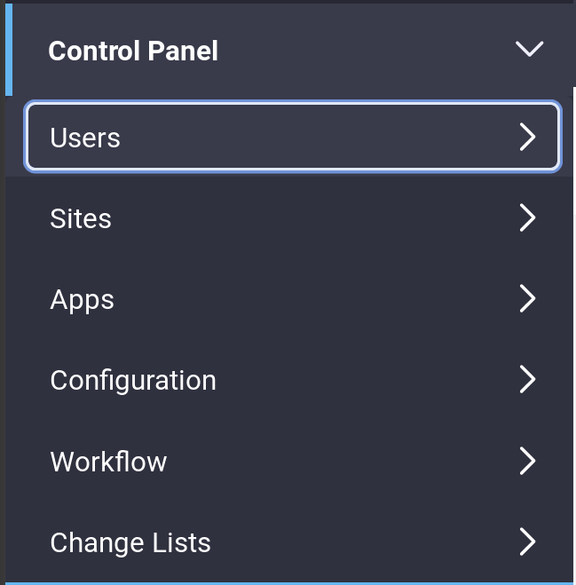

Figure 1: Administrators can access the Control Panel from the Product Menu.

Anonymous User: Anonymous Anonymous is used for the new Managing User Data functionality. Created the first time an administrator clicks Delete Personal Data for a User, Anonymous Anonymous is a deactivated User assigned anonymized assets. The Anonymous User is configurable, so the name and configuration details might be different in your virtual instance.

Begin exploring Liferay’s User Management functionality by reading about adding and editing users.